# CaravanInsurancePolicy

Tinju Jacob

5/3/2022

# Abstract

This data set used in the CoIL 2000 Challenge contains information on customers of an insurance company. The problem entails the task of predicting who would be interested in buying a caravan insurance policy and giving an explanation why. This is a classification problem and requires finding factors that differentiates actual customers from non-customers.

We will try a few classification algorithms and perform model validation using classification error rate from each of these models.

# Description of Data

Dataset contains 85 predictor variables and one response variable. It includes product usage data and socio-demographic data derived from zip area codes.

## Read data

```r
set.seed(123)
ticdata2000_TRAIN <- read.delim(file ="ticdata2000.txt", header = FALSE)
ticeval2000_TEST <- read.delim(file = "ticeval2000.txt", header = FALSE)
tictgts2000_TARGETS_TEST <- read.delim(file = "tictgts2000.txt", header = FALSE) # y2

y1    <- ticdata2000_TRAIN$V86;

y2 <- tictgts2000_TARGETS_TEST$V1
```

# Exploratory Analysis

```r
library(dplyr)
library(tidyverse)
library(ggplot2)
library(randomForest)
library(MASS)
library (gbm)
library(glmnet)
library(corrplot)
library(funModeling)
library(ROSE)
library(pROC)
library(caret)
library(Boruta)
```

Take a look at the summary and structure of the data

```r
glimpse(ticdata2000_TRAIN)
summary(ticdata2000_TRAIN)
str(ticdata2000_TRAIN)
```

The output of the above chunk is huge, hence hidden in this markdown. There are 85 independent variables and a target variable. The target variable in the training data indicated whether that customer has a Caravan insurance or not (1,0) Let’s take a look at the target variable

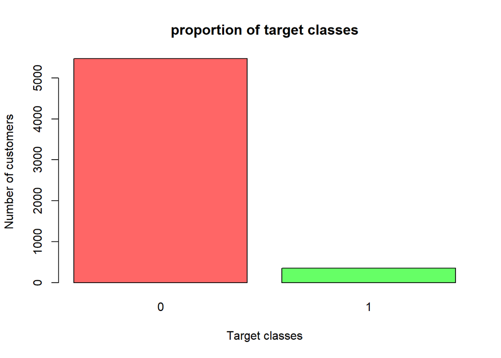

```r
barplot(table(y1),main = "proportion of target classes",xlab = "Target classes",ylab = "Number of customers", col = c("#ff6666","#66ff66"))
```

Clearly there is an imbalance in the target variable. 94% of the datapoints belong to class 0. This is expected as not many people own or insure mobile homes. We will use sampling technique to handle this situation, but before performing any further analysis or feature engineering, I would like to build a base model for benchmarking.

```r
library(rpart)
library(ROSE)
tree1 <- rpart(V86 ~ ., data = ticdata2000_TRAIN, control=rpart.control(minsplit=5,cp=0))
pred.tree1 <- predict(tree1, newdata = ticeval2000_TEST)
y2hat <- ifelse(pred.tree1>0.5,1,0)
confusionMatrix(table(y2hat,y2),positive = '1')
```

```
## Confusion Matrix and Statistics
##
##      y2
## y2hat    0    1
##     0 3622  212
##     1  140   26
##
##                Accuracy : 0.912
##                  95% CI : (0.9028, 0.9206)
##     No Information Rate : 0.9405
##     P-Value [Acc > NIR] : 1.0000000
##
##                   Kappa : 0.0839
##
##  Mcnemar's Test P-Value : 0.0001541
##
##             Sensitivity : 0.1092
##             Specificity : 0.9628
##          Pos Pred Value : 0.1566
##          Neg Pred Value : 0.9447
##              Prevalence : 0.0595
##          Detection Rate : 0.0065
##    Detection Prevalence : 0.0415
##       Balanced Accuracy : 0.5360
##
##        'Positive' Class : 1
##
```

```r
accuracy.meas(response = y2, predicted = y2hat)
```

```
##
## Call:
## accuracy.meas(response = y2, predicted = y2hat)
##
## Examples are labelled as positive when predicted is greater than 0.5
##
## precision: 0.157
## recall: 0.109
## F: 0.064
```

Our aim is to identify policy holders that will be likely to purchase Caravan insurance. The main cost of false positive is sending additional communication to those who may not be candidates for Caravan insurance. However, the cost of false negative is potentially loss of a customer who is likely to purchase a caravan insurance. Therefore we need to focus on a high recall and/or precision, where in true positive is more important than an overall accuracy even at the cost of some false negatives.

Let us remove duplicates if any and convert categorical variables into factors.

```r
#Check for duplicated values

sum(duplicated(ticdata2000_TRAIN))
```

```
## [1] 602
```

```r
training_data <- ticdata2000_TRAIN%>% distinct()
#now without dupl we have 5220 records

#Check for missing values
sum(is.na(training_data))
```

```
## [1] 0
```

```r
#convert categorical columns into factors
cols <- c(1,4:64,86)

training_data <- training_data %>% mutate_at(cols, factor)
str(training_data)
```

```
## 'data.frame':    5220 obs. of  86 variables:
##  $ V1 : Factor w/ 40 levels "1","2","3","4",..: 32 36 36 9 39 22 38 32 32 11 ...
##  $ V2 : int  1 1 1 1 1 1 2 1 1 2 ...
##  $ V3 : int  3 2 2 3 4 2 3 2 2 3 ...
##  $ V4 : Factor w/ 6 levels "1","2","3","4",..: 2 2 2 3 2 1 2 3 4 3 ...
##  $ V5 : Factor w/ 10 levels "1","2","3","4",..: 8 8 8 3 10 5 9 8 8 3 ...
##  $ V6 : Factor w/ 10 levels "0","1","2","3",..: 1 2 1 3 2 1 3 1 1 4 ...
##  $ V7 : Factor w/ 10 levels "0","1","2","3",..: 6 5 5 4 5 6 3 8 2 6 ...
##  $ V8 : Factor w/ 6 levels "0","1","2","3",..: 2 2 3 3 2 1 1 1 4 1 ...
##  $ V9 : Factor w/ 10 levels "0","1","2","3",..: 4 5 5 5 5 6 6 3 7 3 ...
##  $ V10: Factor w/ 10 levels "0","1","2","3",..: 8 7 4 6 8 1 8 8 7 8 ...
##  $ V11: Factor w/ 8 levels "0","1","2","3",..: 1 3 3 3 2 7 3 3 1 1 ...
##  $ V12: Factor w/ 10 levels "0","1","2","3",..: 3 3 5 3 3 4 1 1 4 3 ...
##  $ V13: Factor w/ 10 levels "0","1","2","3",..: 2 1 5 3 3 4 1 1 4 3 ...
##  $ V14: Factor w/ 10 levels "0","1","2","3",..: 3 5 5 4 5 6 4 6 4 3 ...
```

[output cut: 72 more lines]

Further exploration

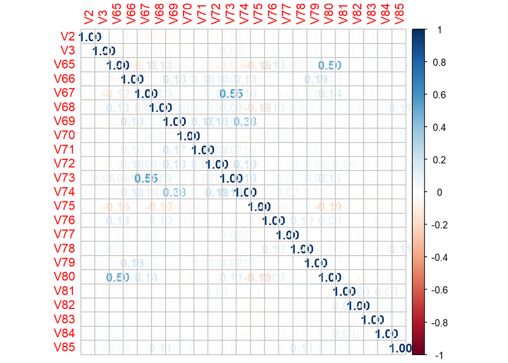

```r
library(caret)
data_numeric <- select_if(training_data, is.numeric)
data_factor <- select_if(training_data, is.factor)

#no corr variables within continuous vars
correlations <- cor(data_numeric)
corrplot(correlations, method="number")
```

```r
policyCor <-  cor(data_numeric)
highlyCorPolicy <- findCorrelation(policyCor, cutoff = .75)
#nothing jumps out
```

We will add V80 - number of fire policies as well as we are investigation contribution to fire policies.

We will see if any of these 6 variables have a strong correlation with the target class 1 1. V47 PPERSAUT Contribution car policies

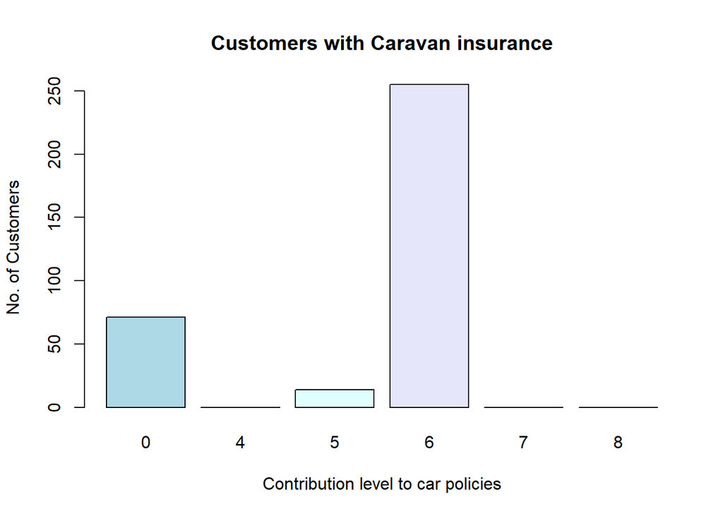

```r
class1 <- training_data[training_data$V86==1,]
class0 <- training_data[training_data$V86==0,]
#freq(class1$V47)
barplot(table(class1$V47),main = "Customers with Caravan insurance",xlab = "Contribution level to car policies",ylab = "No. of Customers",    col = c("lightblue", "mistyrose", "lightcyan",
                "lavender", "cornsilk"))
```

2. V68 APERSAUT Number of car policies

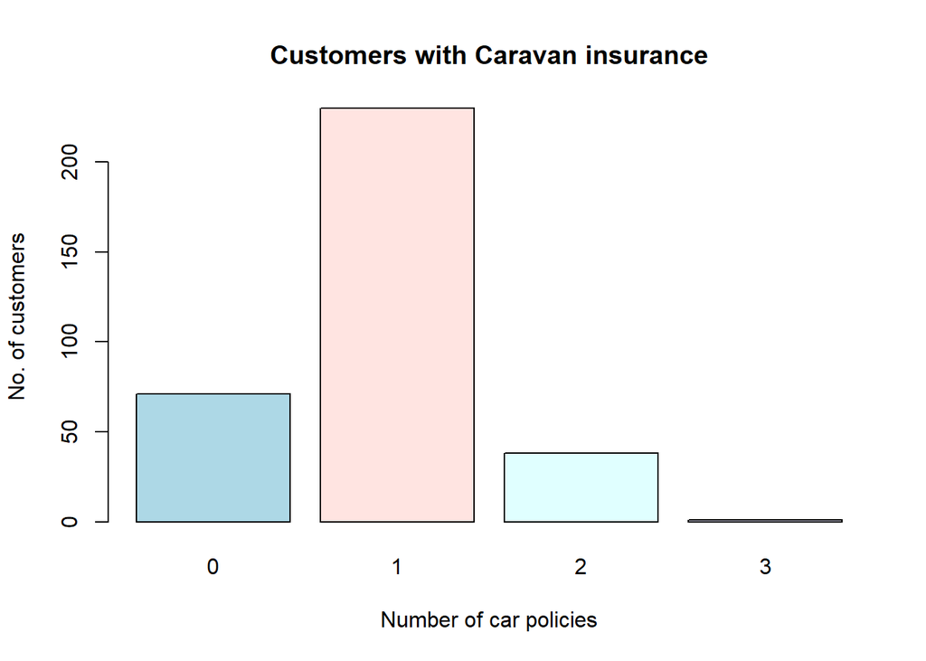

```r
barplot(table(class1$V68),main = "Customers with Caravan insurance",xlab = "Number of car policies",ylab = "No. of customers", col = c("lightblue", "mistyrose", "lightcyan",
                "lavender", "cornsilk"))
```

3. V59 PBRAND Contribution fire policies

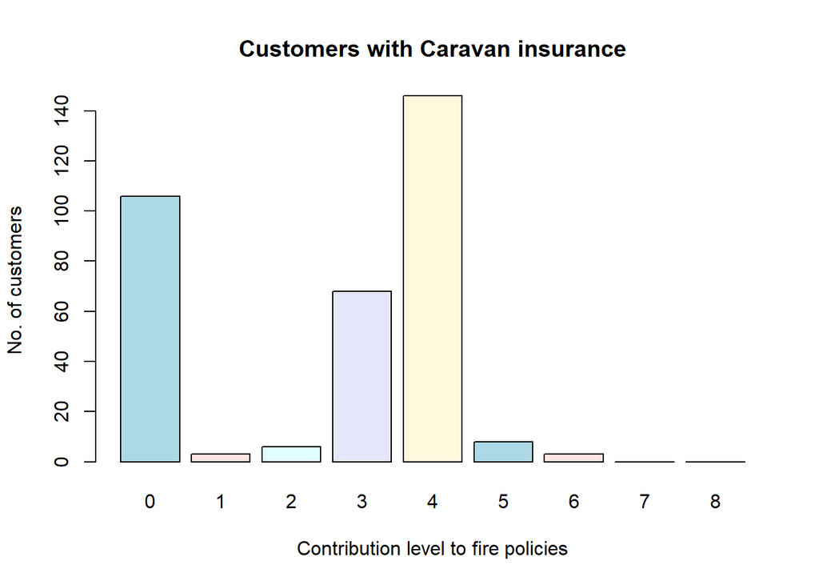

```r
barplot(table(class1$V59),main = "Customers with Caravan insurance",xlab = "Contribution level to fire policies",ylab = "No. of customers", col = c("lightblue", "mistyrose", "lightcyan",
                "lavender", "cornsilk"))
```

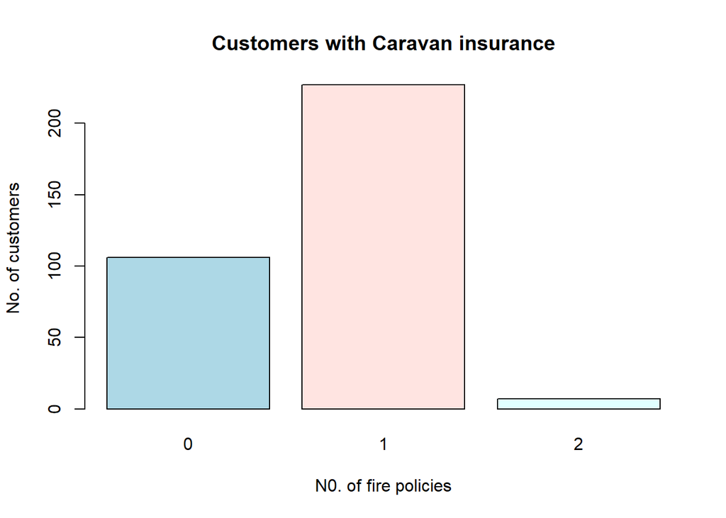

```r
barplot(table(class1$V80),main = "Customers with Caravan insurance",xlab = "N0. of fire policies",ylab = "No. of customers", col = c("lightblue", "mistyrose", "lightcyan",
                "lavender", "cornsilk"))
```

5. V82 APLEZIER Number of boat policies

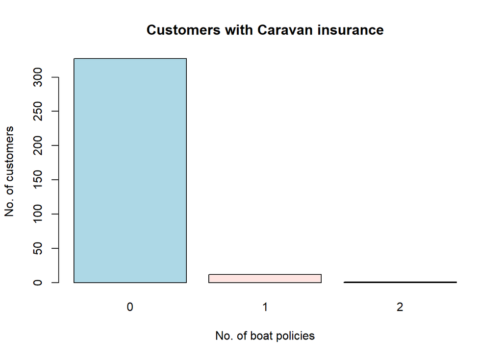

```r
barplot(table(class1$V82),main = "Customers with Caravan insurance",xlab = "No. of boat policies",ylab = "No. of customers", col = c("lightblue", "mistyrose", "lightcyan",
                "lavender", "cornsilk"))
```

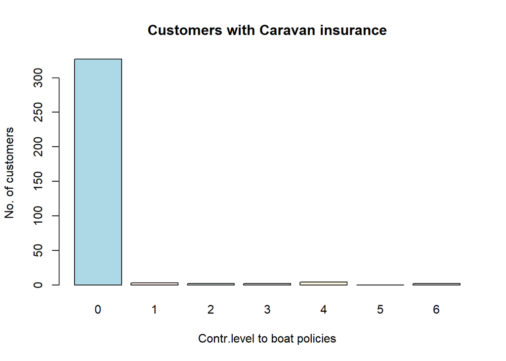

```r
barplot(table(class1$V61),main = "Customers with Caravan insurance",xlab = "Contr.level to boat policies",ylab = "No. of customers", col = c("lightblue", "mistyrose", "lightcyan",
                "lavender", "cornsilk"))
```

take a look at the distribution of numerical discrete variables.

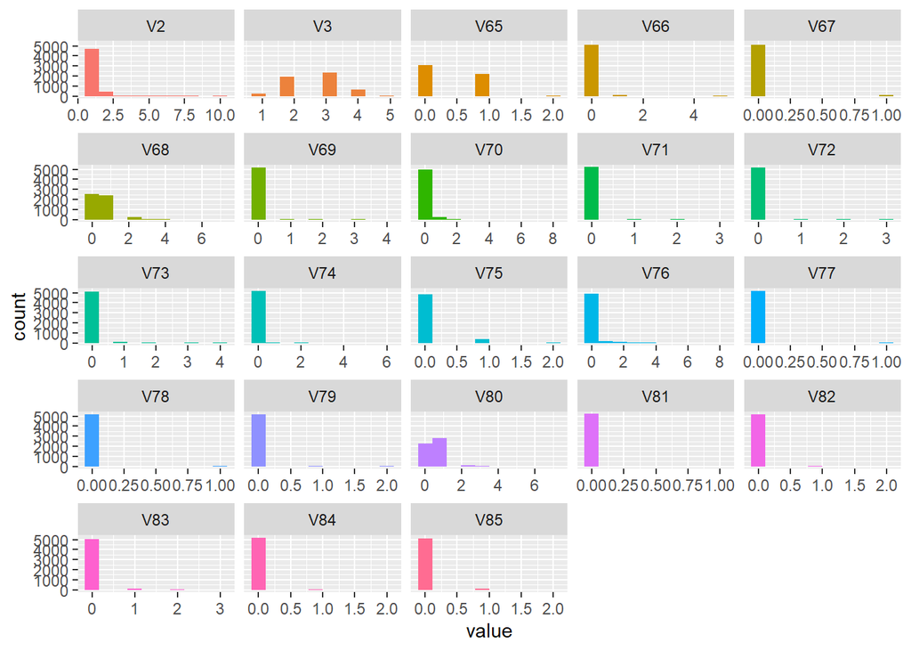

```r
#analyze numerical variables
library(funModeling)
plot_num(training_data)
```

There seems to be multiple predictors with near-zero variance, but none with a single value. I will not remove such variables from the dataset as this is an imbalanced dataset. I may attempt it later after sampling to take care of imbalance.

Convert categorical variables to factors in test dataset

```r
cols <- c(1,4:64)

test_data <- ticeval2000_TEST %>% mutate_at(cols, factor)
```

Fit rpart again on the transformed data

```r
library(rpart)
treeimb <- rpart(V86 ~ ., data = training_data, control=rpart.control(minsplit=5,cp=0))
#pred.treeimb <- predict(treeimb, newdata = test_data)
```

Since the dataset has an imbalance and there are many categorical variables in our data, test data contains levels that are not present in train data. We will handle this situation by defining same levels for test data as in the case of train data. If test data has a level that is not present in train data, it will be marked NA

```r
#Test data contains new levels fora few categorical variables. Therefore manually create levels that are same as that of train data, so the new level in test data will be NA
for(attr in colnames(training_data))
{
  if (is.factor(training_data[[attr]]))
  {
    new.levels <- setdiff(levels(test_data[[attr]]), levels(training_data[[attr]]))
    if ( length(new.levels) > 0 )
    { print(paste(attr, '- new levels'))
      print(c(paste(attr, length(new.levels), 'of new levels, e.g.'), head(new.levels, 2)))
      #levels(test_data[[attr]]) <- union(levels(test_data[[attr]]), levels(training_data[[attr]]))
      test_data[[attr]] <- factor(test_data[[attr]], levels = levels(training_data[[attr]]))
    }
  }
}
```

```
## [1] "V29 - new levels"
## [1] "V29 1 of new levels, e.g." "8"
## [1] "V33 - new levels"
## [1] "V33 1 of new levels, e.g." "9"
## [1] "V41 - new levels"
## [1] "V41 1 of new levels, e.g." "6"
## [1] "V46 - new levels"
## [1] "V46 1 of new levels, e.g." "1"
## [1] "V47 - new levels"
## [1] "V47 1 of new levels, e.g." "9"
## [1] "V50 - new levels"
## [1] "V50 1 of new levels, e.g." "7"
## [1] "V52 - new levels"
## [1] "V52 1 of new levels, e.g." "7"
## [1] "V53 - new levels"
## [1] "V53 1 of new levels, e.g." "1"
## [1] "V60 - new levels"
## [1] "V60 1 of new levels, e.g." "2"
```

```r
#Remove rows with NA's in test data
NAs = which(is.na(test_data),arr.ind=TRUE)[,1]
test_data_cleaned = test_data[-NAs,]
y2_cleaned <- y2[-NAs]
```

We have fixed the problem of level mismatch in test and train data. We can now look at a base rpart model to see how imbalance in data can affect our model

```r
pred.treeimb <- predict(treeimb, newdata = test_data_cleaned)

y2hat <- ifelse(pred.treeimb[,2]>0.5,1,0)
table(y2hat,y2_cleaned)
```

```
##      y2_cleaned
## y2hat    0    1
##     0 3557  206
##     1  191   30
```

```r
accuracy.meas(response = y2hat,predicted = y2_cleaned)
```

```
##
## Call:
## accuracy.meas(response = y2hat, predicted = y2_cleaned)
##
## Examples are labelled as positive when predicted is greater than 0.5
##
## precision: 0.127
## recall: 0.136
## F: 0.066
```

```r
confusionMatrix(table(y2hat,y2_cleaned), positive="1")
```

```
## Confusion Matrix and Statistics
##
##      y2_cleaned
## y2hat    0    1
##     0 3557  206
##     1  191   30
##
##                Accuracy : 0.9004
##                  95% CI : (0.8906, 0.9095)
##     No Information Rate : 0.9408
##     P-Value [Acc > NIR] : 1.0000
##
##                   Kappa : 0.0785
##
##  Mcnemar's Test P-Value : 0.4823
##
##             Sensitivity : 0.12712
##             Specificity : 0.94904
##          Pos Pred Value : 0.13575
##          Neg Pred Value : 0.94526
##              Prevalence : 0.05924
##          Detection Rate : 0.00753
##    Detection Prevalence : 0.05547
##       Balanced Accuracy : 0.53808
##
##        'Positive' Class : 1
##
```

# Data sampling

```r
train_data_balanced <- ovun.sample(V86 ~ ., data = training_data, method = "over",N=2*sum(training_data$V86==0), seed = 1)$data
#train_data_balanced <- ovun.sample(V86 ~ ., data = training_data, method = "under",N=2*(sum(training_data$V86==1)), seed = 1)$data
table(train_data_balanced$V86)
```

```
##
##    0    1
## 4880 4880
```

We have a balanced training set now. Let us fit rpart on this training set to find out if this improves the performance.

```r
tree.balanced <- rpart(V86 ~ ., data = train_data_balanced)
#check accuracy of predictions
pred.tree.balanced <- predict(tree.balanced, newdata = test_data_cleaned)
#select optimal threshold from model fit.
#Remember we need as many true positives as possible without compromising much on the Accuracy and/or #specificity.
rpart.fit <- predict(tree.balanced, type="prob")
roc_curve=roc(train_data_balanced$V86, rpart.fit[,2])
my.coords <- coords(roc=roc_curve, x = "all", transpose = FALSE)
prob_threshold = my.coords[(my.coords$sensitivity >= .5)& (my.coords$specificity >=.7), ][1,1]

pred.tree.class <- ifelse(pred.tree.balanced[,2]>prob_threshold,1,0)
accuracy.meas(response = y2_cleaned, predicted = pred.tree.class)
```

```
##
## Call:
## accuracy.meas(response = y2_cleaned, predicted = pred.tree.class)
##
## Examples are labelled as positive when predicted is greater than 0.5
##
## precision: 0.109
## recall: 0.614
## F: 0.092
```

```r
confusionMatrix(table(pred.tree.class,y2_cleaned),positive = '1')
```

```
## Confusion Matrix and Statistics
##
##                y2_cleaned
## pred.tree.class    0    1
##               0 2559   91
##               1 1189  145
##
##                Accuracy : 0.6787
##                  95% CI : (0.664, 0.6932)
##     No Information Rate : 0.9408
##     P-Value [Acc > NIR] : 1
##
##                   Kappa : 0.0935
##
##  Mcnemar's Test P-Value : <2e-16
##
##             Sensitivity : 0.61441
##             Specificity : 0.68276
##          Pos Pred Value : 0.10870
##          Neg Pred Value : 0.96566
##              Prevalence : 0.05924
##          Detection Rate : 0.03640
##    Detection Prevalence : 0.33484
##       Balanced Accuracy : 0.64859
##
##        'Positive' Class : 1
##
```

```r
selected_variables <-c(rownames(varImp(tree.balanced))[1:31],"V86")
train_selected <- train_data_balanced[,selected_variables]
```

With the transformed input data, the model sensitivity has drastically improved even though the specificity has reduced to some extent. We will use the new training data to try a few other classification models and cross validations to improve the prediction.

# Various classification models

## 1. KNN

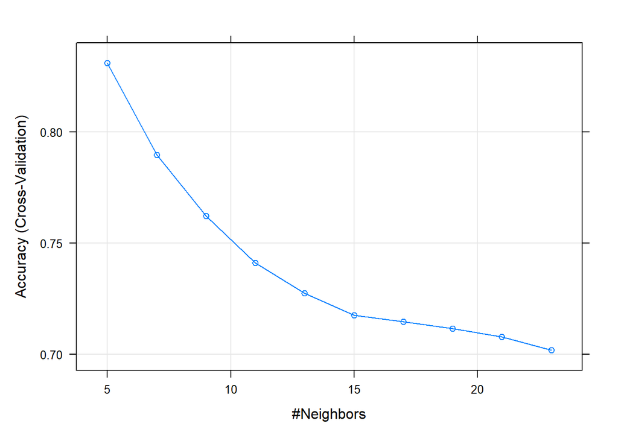

```r
knn_model <- train(
  V86 ~., data = train_data_balanced, method = "knn",
  trControl = trainControl("cv", number = 10),
  tuneLength = 10
)
# Plot model accuracy vs different values of k
plot(knn_model)
```

```r
# Print the best tuning parameter k that
# maximizes model accuracy
knn_model$bestTune
```

```
##   k
## 1 5
```

```r
#check accuracy of predictions
pred.knn <- predict(knn_model, newdata = test_data_cleaned, type = "prob")
#threshold
knn.fit <- predict(knn_model, type="prob")
roc_curve=roc(train_data_balanced$V86, knn.fit[,2])
my.coords <- coords(roc=roc_curve, x = "all", transpose = FALSE)
prob_threshold = my.coords[(my.coords$sensitivity >= .5)& (my.coords$specificity >=.7), ][1,1]

pred.knn.class <- ifelse(pred.knn[,2]>prob_threshold,1,0)
confusionMatrix(table(pred.knn.class,y2_cleaned),positive='1')
```

```
## Confusion Matrix and Statistics
##
##               y2_cleaned
## pred.knn.class    0    1
##              0 2592  117
##              1 1156  119
##
##                Accuracy : 0.6805
##                  95% CI : (0.6657, 0.6949)
##     No Information Rate : 0.9408
##     P-Value [Acc > NIR] : 1
##
##                   Kappa : 0.0639
##
##  Mcnemar's Test P-Value : <2e-16
##
##             Sensitivity : 0.50424
##             Specificity : 0.69157
##          Pos Pred Value : 0.09333
##          Neg Pred Value : 0.95681
##              Prevalence : 0.05924
##          Detection Rate : 0.02987
##    Detection Prevalence : 0.32003
##       Balanced Accuracy : 0.59790
##
##        'Positive' Class : 1
##
```

```r
accuracy.meas(response = y2_cleaned, predicted = pred.knn.class)
```

```
##
## Call:
## accuracy.meas(response = y2_cleaned, predicted = pred.knn.class)
##
## Examples are labelled as positive when predicted is greater than 0.5
##
## precision: 0.093
## recall: 0.504
## F: 0.079
```

## 2. logistic regression

```r
glm_model <- glm(V86 ~.,family=binomial(link='logit'),data=train_data_balanced)
#summary(glm_model)====
glm_probabilities <- predict(glm_model, test_data_cleaned, type = "response")
#prob threshold
glm.fit <- predict(glm_model, type="response")
roc_curve=roc(train_data_balanced$V86, glm.fit)
my.coords <- coords(roc=roc_curve, x = "all", transpose = FALSE)
prob_threshold = my.coords[(my.coords$sensitivity >= .5)& (my.coords$specificity >=.7), ][1,1]

glm_class <- ifelse(glm_probabilities > prob_threshold, 1, 0)
confusionMatrix(table(glm_class,y2_cleaned),positive = '1')
```

```
## Confusion Matrix and Statistics
##
##          y2_cleaned
## glm_class    0    1
##         0 2543  100
##         1 1205  136
##
##                Accuracy : 0.6724
##                  95% CI : (0.6576, 0.687)
##     No Information Rate : 0.9408
##     P-Value [Acc > NIR] : 1
##
##                   Kappa : 0.0798
##
##  Mcnemar's Test P-Value : <2e-16
##
##             Sensitivity : 0.57627
##             Specificity : 0.67850
##          Pos Pred Value : 0.10142
##          Neg Pred Value : 0.96216
##              Prevalence : 0.05924
##          Detection Rate : 0.03414
##    Detection Prevalence : 0.33660
##       Balanced Accuracy : 0.62738
##
##        'Positive' Class : 1
##
```

```r
accuracy.meas(response = y2_cleaned, predicted = glm_class)
```

```
##
## Call:
## accuracy.meas(response = y2_cleaned, predicted = glm_class)
##
## Examples are labelled as positive when predicted is greater than 0.5
##
## precision: 0.101
## recall: 0.576
## F: 0.086
```

### 2b. logistic regression with factor selection

Earlier in the data exploration phase, we saw that details around car insurance, boat insurance and fire insurance may have notable effect on the target class. We will now perform glm with these variables.

```r
glm_model2 <- glm(V86 ~ V47+V68+V59+V61+V82+V80,family=binomial(link='logit'),data=train_data_balanced)
#summary(glm_model)====
glm_probabilities2 <- predict(glm_model2, test_data_cleaned, type = "response")
#prob threshold
glm.fit2 <- predict(glm_model2, type="response")
roc_curve=roc(train_data_balanced$V86, glm.fit2)
my.coords <- coords(roc=roc_curve, x = "all", transpose = FALSE)
prob_threshold = my.coords[(my.coords$sensitivity >= .55)& (my.coords$specificity >=.7), ][1,1]

glm_class2 <- ifelse(glm_probabilities2 > prob_threshold, 1, 0)
confusionMatrix(table(glm_class2,y2_cleaned),positive = '1')
```

```
## Confusion Matrix and Statistics
##
##           y2_cleaned
## glm_class2    0    1
##          0 3085  126
##          1  663  110
##
##                Accuracy : 0.802
##                  95% CI : (0.7892, 0.8142)
##     No Information Rate : 0.9408
##     P-Value [Acc > NIR] : 1
##
##                   Kappa : 0.14
##
##  Mcnemar's Test P-Value : <2e-16
##
##             Sensitivity : 0.46610
##             Specificity : 0.82311
##          Pos Pred Value : 0.14230
##          Neg Pred Value : 0.96076
##              Prevalence : 0.05924
##          Detection Rate : 0.02761
##    Detection Prevalence : 0.19403
##       Balanced Accuracy : 0.64460
##
##        'Positive' Class : 1
##
```

```r
accuracy.meas(response = y2_cleaned, predicted = glm_class2)
```

```
##
## Call:
## accuracy.meas(response = y2_cleaned, predicted = glm_class2)
##
## Examples are labelled as positive when predicted is greater than 0.5
##
## precision: 0.142
## recall: 0.466
## F: 0.109
```

## 4a. Naive Bayes with select variables

```r
library(e1071)
library(naivebayes)
test_data_cleaned <- rbind(train_data_balanced[1,-86 ],test_data_cleaned)
test_data_cleaned <- test_data_cleaned[-1,]
#Use Variableimportance from rpart for variable selection.
naive_model <- naive_bayes(V86 ~ V47+V59+V61+V68+V80+V82, data = train_data_balanced, usekernel = T)
naive_prob <- predict(naive_model, test_data_cleaned,type = "prob")

#Threshold
naive.fit <- predict(naive_model, type="prob")
roc_curve=roc(train_data_balanced$V86, naive.fit[,2])
my.coords <- coords(roc=roc_curve, x = "all", transpose = FALSE)
prob_threshold = my.coords[(my.coords$sensitivity >= .5)& (my.coords$specificity >=.7), ][1,1]

naive_class <- ifelse(naive_prob[,2] > prob_threshold,1,0)
confusionMatrix(table(naive_class,y2_cleaned),positive = '1')
```

```
## Confusion Matrix and Statistics
##
##            y2_cleaned
## naive_class    0    1
##           0 3033  119
##           1  715  117
##
##                Accuracy : 0.7907
##                  95% CI : (0.7777, 0.8032)
##     No Information Rate : 0.9408
##     P-Value [Acc > NIR] : 1
##
##                   Kappa : 0.1397
##
##  Mcnemar's Test P-Value : <2e-16
##
##             Sensitivity : 0.49576
##             Specificity : 0.80923
##          Pos Pred Value : 0.14062
##          Neg Pred Value : 0.96225
##              Prevalence : 0.05924
##          Detection Rate : 0.02937
##    Detection Prevalence : 0.20884
##       Balanced Accuracy : 0.65250
##
##        'Positive' Class : 1
##
```

```r
accuracy.meas(response = y2_cleaned, predicted = naive_class)
```

```
##
## Call:
## accuracy.meas(response = y2_cleaned, predicted = naive_class)
##
## Examples are labelled as positive when predicted is greater than 0.5
##
## precision: 0.141
## recall: 0.496
## F: 0.110
```

## 4b. Naive Bayes with all variables

```r
naive_model_all <- naive_bayes(V86 ~ ., data = train_data_balanced, usekernel = T)
naive_prob_all <- predict(naive_model_all, test_data_cleaned,type = "prob")

#Threshold
naive.fit_all <- predict(naive_model_all, type="prob")
my.coords <- coords(roc=roc_curve, x = "all", transpose = FALSE)
prob_threshold = my.coords[(my.coords$sensitivity >= .5)& (my.coords$specificity >=.7), ][1,1]

naive_class_all <- ifelse(naive_prob_all[,2] > prob_threshold,1,0)
confusionMatrix(table(naive_class_all,y2_cleaned),positive = '1')
```

```
## Confusion Matrix and Statistics
##
##                y2_cleaned
## naive_class_all    0    1
##               0 3344  157
##               1  404   79
##
##                Accuracy : 0.8592
##                  95% CI : (0.848, 0.8698)
##     No Information Rate : 0.9408
##     P-Value [Acc > NIR] : 1
##
##                   Kappa : 0.1523
##
##  Mcnemar's Test P-Value : <2e-16
##
##             Sensitivity : 0.33475
##             Specificity : 0.89221
##          Pos Pred Value : 0.16356
##          Neg Pred Value : 0.95516
##              Prevalence : 0.05924
##          Detection Rate : 0.01983
##    Detection Prevalence : 0.12123
##       Balanced Accuracy : 0.61348
##
##        'Positive' Class : 1
##
```

```r
accuracy.meas(response = y2_cleaned, predicted = naive_class_all)
```

```
##
## Call:
## accuracy.meas(response = y2_cleaned, predicted = naive_class_all)
##
## Examples are labelled as positive when predicted is greater than 0.5
##
## precision: 0.164
## recall: 0.335
## F: 0.110
```

## 5. GBM

```r
training_data_gbm = train_data_balanced
training_data_gbm$V86 <- as.numeric(training_data_gbm$V86, start.at=0)-1
gbm2.train <- gbm(V86 ~ .,data=training_data_gbm,
                       distribution = 'bernoulli',
                       n.trees =5000,
                       shrinkage = 0.01,
                       interaction.depth = 3,
                        cv.folds = 10,
                        class.stratify.cv = TRUE)

## Model Inspection
#3esummary(gbm2.train)
## Find the estimated optimal number of iterations
perf_gbm2 = gbm.perf(gbm2.train, method="cv")
```

[figure not shown]

```r
cat("The estimated optimal number of iterations is", perf_gbm2)
```

```
## The estimated optimal number of iterations is 5000
```

```r
#Prob threshold
gbm.fit <- predict(gbm2.train,n.trees=perf_gbm2, type="response")
roc_curve=roc(train_data_balanced$V86, gbm.fit)
my.coords <- coords(roc=roc_curve, x = "all", transpose = FALSE)
prob_threshold = my.coords[(my.coords$sensitivity >= .5)& (my.coords$specificity >=.7), ][1,1]

#Test error
gbm_prob <- predict(gbm2.train,newdata = test_data_cleaned, n.trees=perf_gbm2, type="response")
gbm_class <- ifelse(gbm_prob > prob_threshold, 1, 0)
confusionMatrix(table(gbm_class,y2_cleaned),positive = '1')
```

```
## Confusion Matrix and Statistics
##
##          y2_cleaned
## gbm_class    0    1
##         0 2479   89
##         1 1269  147
##
##                Accuracy : 0.6591
##                  95% CI : (0.6442, 0.6739)
##     No Information Rate : 0.9408
##     P-Value [Acc > NIR] : 1
##
##                   Kappa : 0.0851
##
##  Mcnemar's Test P-Value : <2e-16
##
##             Sensitivity : 0.62288
##             Specificity : 0.66142
##          Pos Pred Value : 0.10381
##          Neg Pred Value : 0.96534
##              Prevalence : 0.05924
##          Detection Rate : 0.03690
##    Detection Prevalence : 0.35542
##       Balanced Accuracy : 0.64215
##
##        'Positive' Class : 1
##
```

```r
accuracy.meas(response = y2_cleaned, predicted = gbm_class)
```

```
##
## Call:
## accuracy.meas(response = y2_cleaned, predicted = gbm_class)
##
## Examples are labelled as positive when predicted is greater than 0.5
##
## precision: 0.104
## recall: 0.623
## F: 0.089
```

## 3. Random Forest

```r
RF_model <- randomForest(V86 ~., data=train_data_balanced, importance=TRUE, ntree=1000)
importance(RF_model)
```

```
##                 0         1 MeanDecreaseAccuracy MeanDecreaseGini
## V1   23.385902949 67.082538            70.912538     438.81537208
## V2    1.359184225 27.399823            27.863401       9.69521163
## V3   -2.806687194 31.847281            31.957939      17.31744002
## V4   -5.992721899 34.487203            34.508448      22.06094233
## V5    0.618686808 43.896257            43.524462     109.19658605
## V6   -6.867497764 34.723125            35.114787      28.89738103
## V7   -7.628476561 57.005021            57.203216      96.90125597
## V8   -5.289476843 31.676100            31.736387      39.07461673
## V9  -11.148282199 58.577398            58.073122      86.39071586
## V10  -4.646859931 51.221162            51.231505      79.70238641
## V11  -6.597796864 33.019523            33.370076      24.56020791
## V12  -7.152870663 46.501606            47.211461      58.61858267
## V13 -12.610401047 49.506275            49.113536      60.61495241
## V14  -9.881191985 61.833600            61.520456      79.06544964
## V15 -12.437566812 66.664015            66.695775     105.26426419
## V16  -9.013190220 34.130126            34.304209      55.69678811
## V17  -7.871873724 53.815170            54.008746      81.85566275
## V18 -17.114637307 49.930579            49.748004     132.37864158
## V19 -17.964921336 49.575993            49.837143      80.26805653
## V20  -1.128891303 29.890819            30.178855      16.76576647
## V21  -3.841362779 26.483666            26.314746      30.10833424
## V22 -14.825998282 61.856955            61.662843      98.47622639
## V23  -6.677125657 47.671493            47.788114      98.78562803
## V24 -11.910112531 46.094687            45.904337      72.51884027
## V25 -12.413280450 38.141661            38.501970      64.64768530
## V26  -9.276558757 42.349000            42.672731      56.55462353
## V27 -11.597843004 56.109046            55.945660      60.89199436
## V28 -13.322837562 52.348489            52.138408     105.82365622
## V29  -6.263180457 36.522267            36.722893      46.97090805
## V30 -16.259857625 42.491713            42.463221     121.57513687
## V31 -13.505123405 42.852364            42.787118     121.29515864
## V32  -6.690579157 33.097746            33.090694      76.30746786
## V33  -9.047207959 46.873760            46.865693      40.35671388
## V34 -10.289284036 34.909436            34.985393      71.30618319
## V35 -12.436622956 44.494893            44.506291      71.65913460
## V36 -14.250325353 44.747352            44.723798      72.20405971
## V37 -16.017331230 37.470899            37.481055     112.14392996
## V38 -11.284086209 62.672843            62.577798      94.88328369
## V39 -18.115492750 40.678201            40.548987      97.63078395
```

[output cut: 31 more lines]

```
## V71   0.000000000  1.000500             1.000500       0.04134953
## V72  -0.135610120 20.614471            20.506263       4.36690258
## V73   3.924898985 20.155491            20.315577       5.14203212
## V74   0.005890869  1.734625             1.338359       0.15576179
## V75  17.550817723 30.049101            30.506752      21.95585574
## V76   0.372149013 42.246124            41.606483      16.85418775
## V77  -1.338269822  7.172994             6.865081       1.21018767
## V78   0.312938735 20.289173            20.167955       3.17374898
## V79   2.007708922 20.150828            19.963606       3.94789142
## V80 -12.060263354 26.768032            26.939606      45.31422772
## V81  -0.429566199  7.212567             7.177264       0.52355179
## V82  13.466703711 28.908413            27.570482      19.67634987
## V83  -0.206583202 37.758299            37.297723      12.08805315
## V84   1.156669401 21.178002            20.941332       3.20778581
## V85   5.944412378 31.107039            30.399921       8.77425066
```

```r
#RFimp = data.frame(importance(RF_model))
#RFimp[order(-RFimp$MeanDecreaseGini),]

RF_prob = predict(RF_model, test_data_cleaned,type = "prob")
#Threshold
RF.fit <- predict(RF_model, type="prob")
roc_curve=roc(train_data_balanced$V86, RF.fit[,2])
my.coords <- coords(roc=roc_curve, x = "all", transpose = FALSE)
prob_threshold = my.coords[(my.coords$sensitivity >= .5)& (my.coords$specificity >=.75), ][1,1]

RF_class = ifelse(RF_prob[,2]>prob_threshold,1,0)
RF_class = predict(RF_model, test_data_cleaned,type = "class")
confusionMatrix(table(RF_class,y2_cleaned),positive = '1')
```

```
## Confusion Matrix and Statistics
##
##         y2_cleaned
## RF_class    0    1
##        0 3567  195
##        1  181   41
##
##                Accuracy : 0.9056
##                  95% CI : (0.8961, 0.9145)
##     No Information Rate : 0.9408
##     P-Value [Acc > NIR] : 1.0000
##
##                   Kappa : 0.129
##
##  Mcnemar's Test P-Value : 0.5026
##
##             Sensitivity : 0.17373
##             Specificity : 0.95171
##          Pos Pred Value : 0.18468
##          Neg Pred Value : 0.94817
##              Prevalence : 0.05924
##          Detection Rate : 0.01029
##    Detection Prevalence : 0.05572
##       Balanced Accuracy : 0.56272
##
##        'Positive' Class : 1
##
```

```r
accuracy.meas(response = y2_cleaned, predicted = RF_class)
```

```
##
## Call:
## accuracy.meas(response = y2_cleaned, predicted = RF_class)
##
## Examples are labelled as positive when predicted is greater than 0.5
##
## precision: 0.059
## recall: 1.000
## F: 0.056
```

The sensitivity has improved with no much reduction in accuracy.

## Naive with variables with high importance from Random forest

```r
naive_model_imp <- naive_bayes(V86 ~ V1+V47+V59+V68, data = train_data_balanced, usekernel = T)
naive_prob_imp <- predict(naive_model_imp, test_data_cleaned,type = "prob")

#Threshold
naive.fit_imp <- predict(naive_model_imp, type="prob")
my.coords <- coords(roc=roc_curve, x = "all", transpose = FALSE)
prob_threshold = my.coords[(my.coords$sensitivity >= .5)& (my.coords$specificity >=.7), ][1,1]

naive_class_imp <- ifelse(naive_prob_imp[,2] > prob_threshold,1,0)
confusionMatrix(table(naive_class_imp,y2_cleaned),positive = '1')
```

```
## Confusion Matrix and Statistics
##
##                y2_cleaned
## naive_class_imp    0    1
##               0  748   12
##               1 3000  224
##
##                Accuracy : 0.244
##                  95% CI : (0.2307, 0.2576)
##     No Information Rate : 0.9408
##     P-Value [Acc > NIR] : 1
##
##                   Kappa : 0.0215
##
##  Mcnemar's Test P-Value : <2e-16
##
##             Sensitivity : 0.94915
##             Specificity : 0.19957
##          Pos Pred Value : 0.06948
##          Neg Pred Value : 0.98421
##              Prevalence : 0.05924
##          Detection Rate : 0.05622
##    Detection Prevalence : 0.80924
##       Balanced Accuracy : 0.57436
##
##        'Positive' Class : 1
##
```

```r
accuracy.meas(response = y2_cleaned, predicted = naive_class_imp)
```

```
##
## Call:
## accuracy.meas(response = y2_cleaned, predicted = naive_class_imp)
##
## Examples are labelled as positive when predicted is greater than 0.5
##
## precision: 0.069
## recall: 0.949
## F: 0.065
```

## Partial dependency plots

Based on our analysis so far variables related to car policies, boat policies and fire policies are the variables with good predictive power. We will create partial dependency plot of these variables based on Random forest model to see the importance of these variables on classifying a data point as potential customer for Caravan insurance.

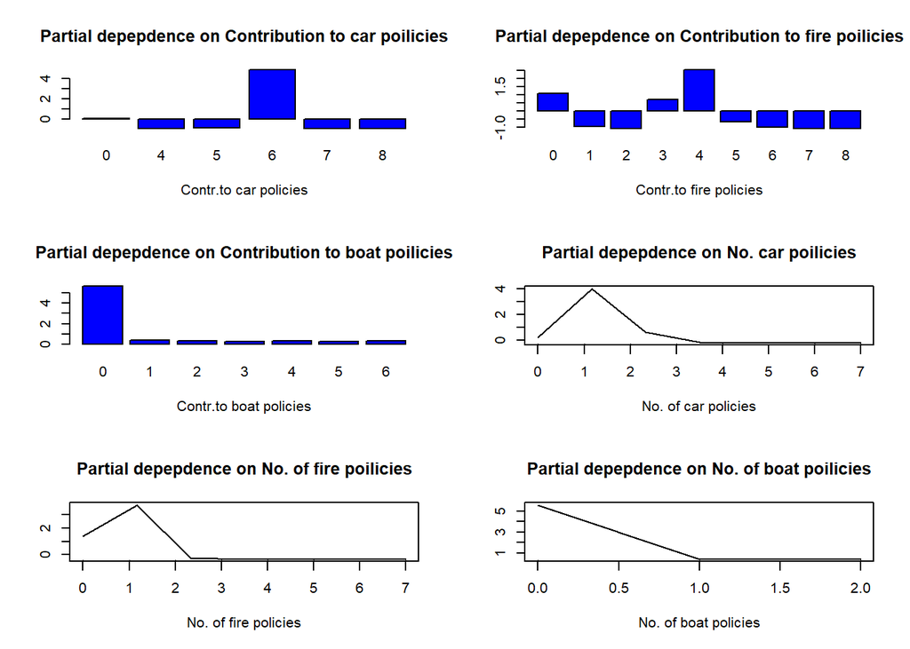

```r
par(mfrow=c(3,2))
partialPlot(RF_model, pred.data = train_data_balanced, x.var = "V47",which.class = 1, xlab="Contr.to car policies", main="Partial depepdence on Contribution to car poilicies")
partialPlot(RF_model, pred.data = train_data_balanced, x.var = "V59",which.class = 1, xlab="Contr.to fire policies", main="Partial depepdence on Contribution to fire poilicies")
partialPlot(RF_model, pred.data = train_data_balanced, x.var = "V61",which.class = 1, xlab="Contr.to boat policies", main="Partial depepdence on Contribution to boat poilicies")
partialPlot(RF_model, pred.data = train_data_balanced, x.var = "V68",which.class = 1, xlab="No. of car policies", main="Partial depepdence on No. car poilicies")
partialPlot(RF_model, pred.data = train_data_balanced, x.var = "V80",which.class = 1, xlab="No. of fire policies", main="Partial depepdence on No. of fire poilicies")
partialPlot(RF_model, pred.data = train_data_balanced, x.var = "V82",which.class = 1, xlab="No. of boat policies", main="Partial depepdence on No. of boat poilicies")
```

This shows that customers who have a contribution level of 6($1000 - $4999) to car policies are more likely than others to purchase a Caravan insurance. Also, Customers who have a fire policy with a contribution of $200-499 have a positive influence on the likelihood of purchasing a caravan insurance. Boat policies may not have much importance in prediction as 99% of the entire list of customers fall in the 0 category

#Results

Naïve Bayes and Logistic Regression with variable selection performed the best. These models were not very computationally intensive and predicted close to 120 customers as true positives.

[figure not shown]

Comparison of model accuracy.